# Biases of Two Coins

This is an example from Kruschke(2015)[^1], section 7.4. The model is implemented in JAGS in section 8.4.

The aim is to estimate the difference of biases between two coins (or subjects). The following data are provided. The column `y` contains the outcomes, with $1$ meaning heads and $0$ meaning tails. The column `s` contains the two coins’ identifiers. Each subject (coin) corresponds to several trials (tosses).

```r
dataCoin <- read.csv('z6N8z2N7.csv')
dataCoin
```

```
##    y        s
## 1  1 Reginald
## 2  0 Reginald
## 3  1 Reginald
## 4  1 Reginald
## 5  1 Reginald
## 6  1 Reginald
## 7  1 Reginald
## 8  0 Reginald
## 9  0     Tony
## 10 0     Tony
## 11 1     Tony
## 12 0     Tony
## 13 0     Tony
## 14 1     Tony
## 15 0     Tony
```

Suppose:

$\theta_1$ is the probability for coin 1 to land head

$\theta_2$ is the probability for coin 2 to land head

We wish to estimate the distributions of the two parameters, $\theta_1$ and $\theta_2$, given the above data.

## Exact posterior

Suppose:

Coin 1 is tossed $N_1$ times and $z_1$ heads are observed.

Coin 2 is tossed $N_2$ times, independent of coin 1, and $z_2$ heads are observed.

Let $Data = D = \{z_1, N_1, z_2, N_2\}$.

If we choose the prior distributions of $\theta_1$ and $\theta_2$ to be $beta(a_1, b_1)$ and $beta(a_2, b_2)$, respectively, the posterior joint distribution of $\theta_1$ and $\theta_2$ is shown to be $p(\theta_1, \theta_2 | D) = beta(\theta_1|z_1+a_1, N_1-z_1+b_1) \cdot beta(\theta_2|z_2+a_2, N_2-z_2+b_2)$

## Using NIMBLE

```r
library(nimble)
## modelCode
coinCode <- nimbleCode({
  for (i in 1:Nsubj){
    theta[i] ~ dbeta(2, 2)    # prior distributions the two parameters
  }
    for (i in 1:Ntotal){
        y[i] ~ dbern(prob = theta[s[i]])    # likelihoods of the outcomes based on the subjects
    }
})

## define additional information needed for the model
## data
coinData <- list(y = dataCoin$y)

## constants of the model (e.g. number of observations, fixed values)
coinConsts <- list(s = as.numeric(dataCoin$s), Ntotal = nrow(dataCoin), Nsubj = length(unique(dataCoin$s)))

## values to initialize the algorithm
coinInits <- list(theta = c(0.5, 0.5))
```

```r
nChains <- 1
nBurnin <- 1000
nIter <- 5000

## fast use of NIMBLE (one-line invocation)
mcmc.out <- nimbleMCMC(code = coinCode, constants = coinConsts,
                        data = coinData, inits = coinInits,
                        niter = nIter, nburnin = nBurnin, nchains = nChains,
                        monitors = c('theta'))
```

```
## defining model...
```

```
## building model...
```

```
## setting data and initial values...
```

[output not shown]

```
## |-------------|-------------|-------------|-------------|
## |-------------------------------------------------------|
```

The result is a matrix. Each row corresponds to one iteration, while each column corresponds to one parameter.

```r
head(mcmc.out)
```

```
##       theta[1]  theta[2]
## [1,] 0.6047588 0.4434110
## [2,] 0.5104288 0.3175004
## [3,] 0.6074305 0.3303002
## [4,] 0.6445649 0.6208110
## [5,] 0.5312483 0.2318605
## [6,] 0.6570725 0.4044447
```

One can plot the result.

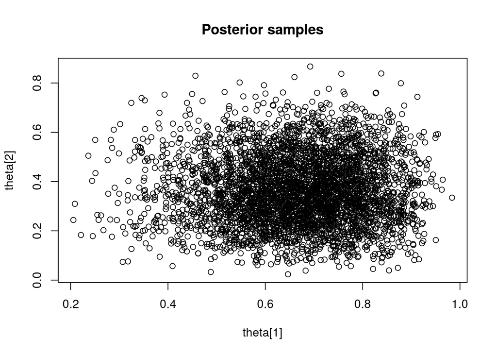

```r
plot(mcmc.out, type = "p", main = "Posterior samples")
```

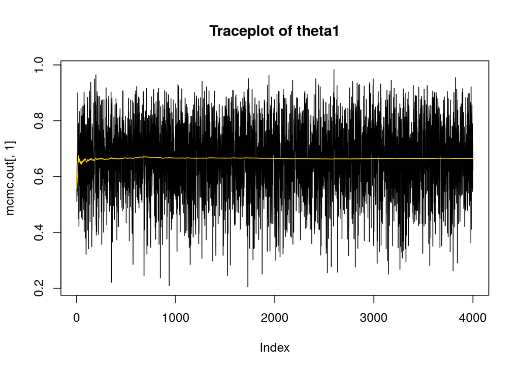

```r
plot(mcmc.out[,1], type = "l", main = "Traceplot of theta1")
lines(cumsum(mcmc.out[,1])/1:length(mcmc.out[,1]), col = "gold")
```

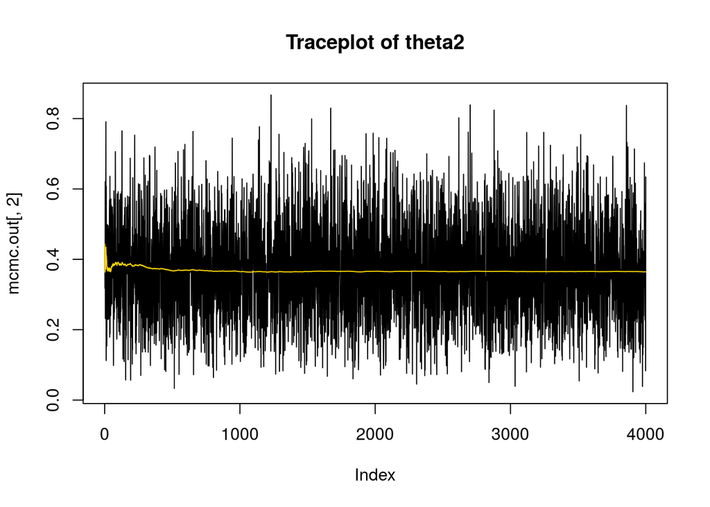

```r
plot(mcmc.out[,2], type = "l", main = "Traceplot of theta2")
lines(cumsum(mcmc.out[,2])/1:length(mcmc.out[,2]), col = "gold")
```

Marginal posterior distributions of $\theta_1$ and $\theta_2$

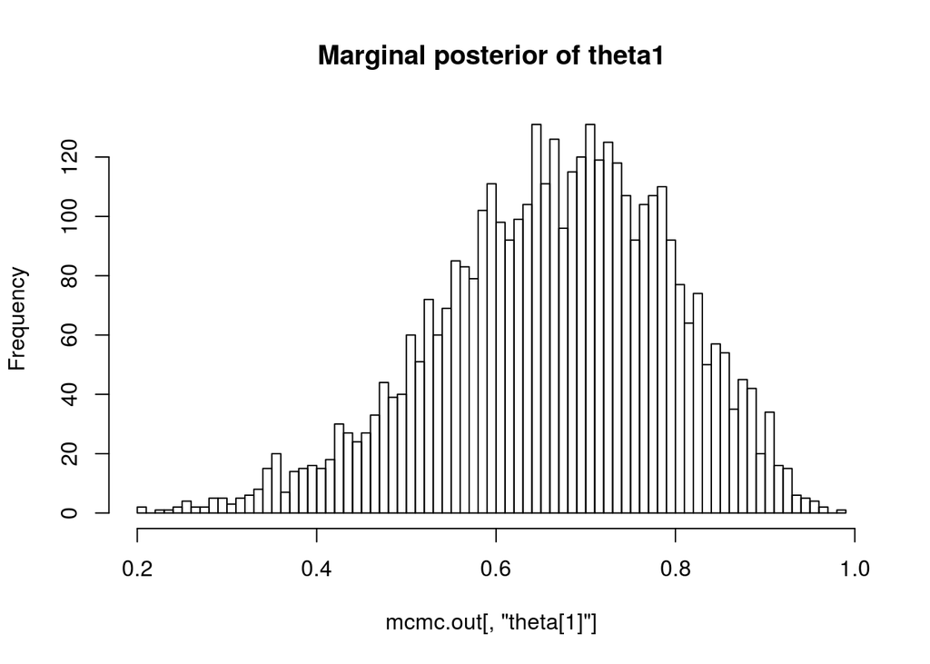

```r
hist(mcmc.out[,'theta[1]'], main = "Marginal posterior of theta1", breaks = 100)
```

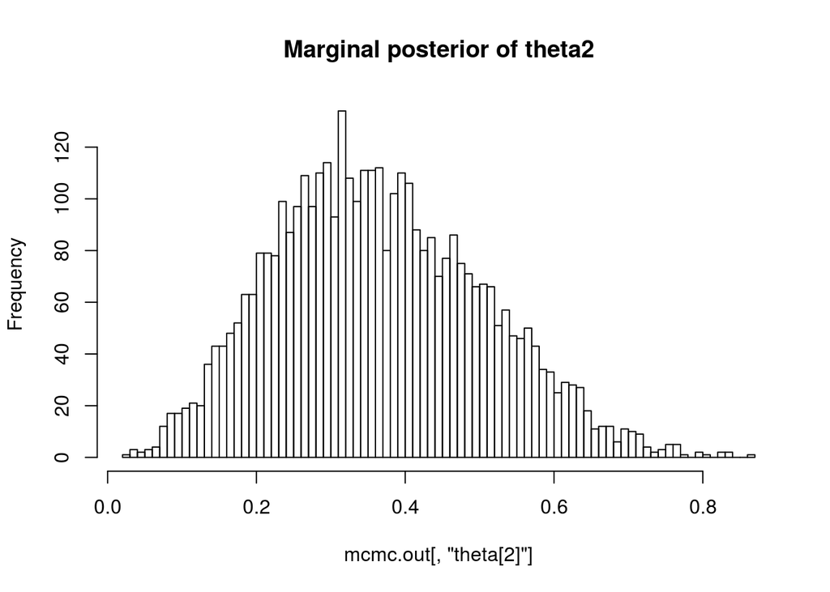

```r
hist(mcmc.out[,'theta[2]'], main = "Marginal posterior of theta2", breaks = 100)
```

[^1]: Kruschke, J.K.,2015. Doing Bayesian data analysis: a tutorial with R, JAGS, and stan. 2E [edition]. Academic Press.